# Final Project QMEE

Alejandro Rojas

File import into R maintaining the first row as header for the columns. Also the samples from Arkansas 2011 were removed since this samples only came form a single field, not complying with the same sampling parameters used for the other samples.

```r
length(oomy_data$State)
```

```
## [1] 112
```

```r
stargazer(oomy_data, summary=TRUE, type="text")
```

```
##
## ============================================================
## Statistic           N    Mean    St. Dev.   Min       Max
## ------------------------------------------------------------
## Year               112 2,011.482  0.502    2,011     2,012
## Number_of_isolates 112  26.455    23.703     1        191
## Number_of_Species  112   7.795    3.708      1        18
## Long               112  -92.266   4.680   -100.820  -84.014
## Lat                112  41.921    3.065    33.797   47.957
## OTU                112  13.768    8.773      1        57
## Chao               112  52.488    79.252   1.000    666.000
## chao_lci           112  27.178    40.926   0.000    366.598
## chao_hci           112  135.605  166.189   0.000   1,236.551
## shannon            112   2.123    0.677    0.000     3.583
## shannon_lci        112   1.729    0.741    0.000     3.356
## shannon_hci        112   2.518    0.630    0.000     3.811
## Precipitation      112  89.211    32.255   35.570   203.620
## Temp               112  18.562    2.538    13.610   24.970
## ------------------------------------------------------------
```

Transform year data into factor and data type is checked after transformation.

Histogram representing the distribution of number of species found per year:

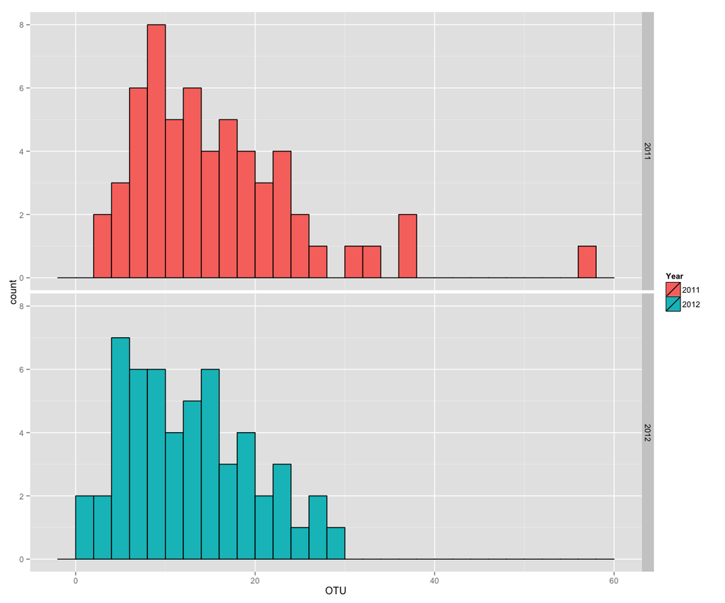

Box plots for number of species in each state, compiling the 6 fields per state

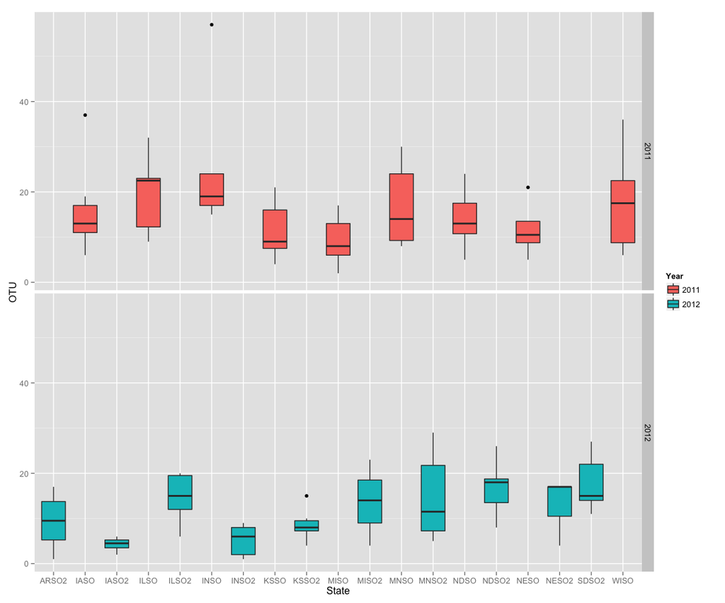

```r
#Boxplot for the number of species per state
ggplot(data=oomy_data, aes(y=OTU, x=State)) +
  geom_boxplot(aes(fill=Year)) + labs(y="OTU") + facet_grid(Year ~ .)
```

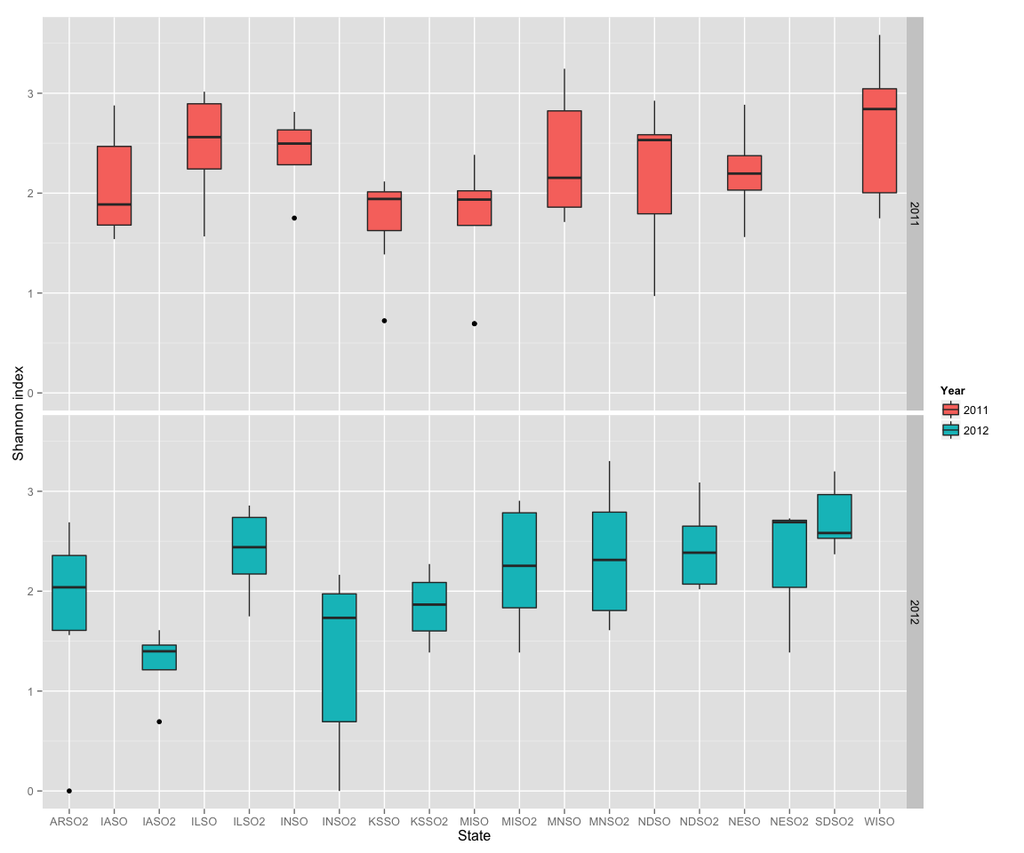

```r
#Boxplot for the shannon diversity index per state
ggplot(data=oomy_data, aes(y=shannon, x=State)) +
  geom_boxplot(aes(fill=Year)) + labs(y="Shannon index") + facet_grid(Year ~ .)
```

Plotting the temperature against the number of species observed or using shannon diversity index, there was not a striking pattern that correlates the two factors.

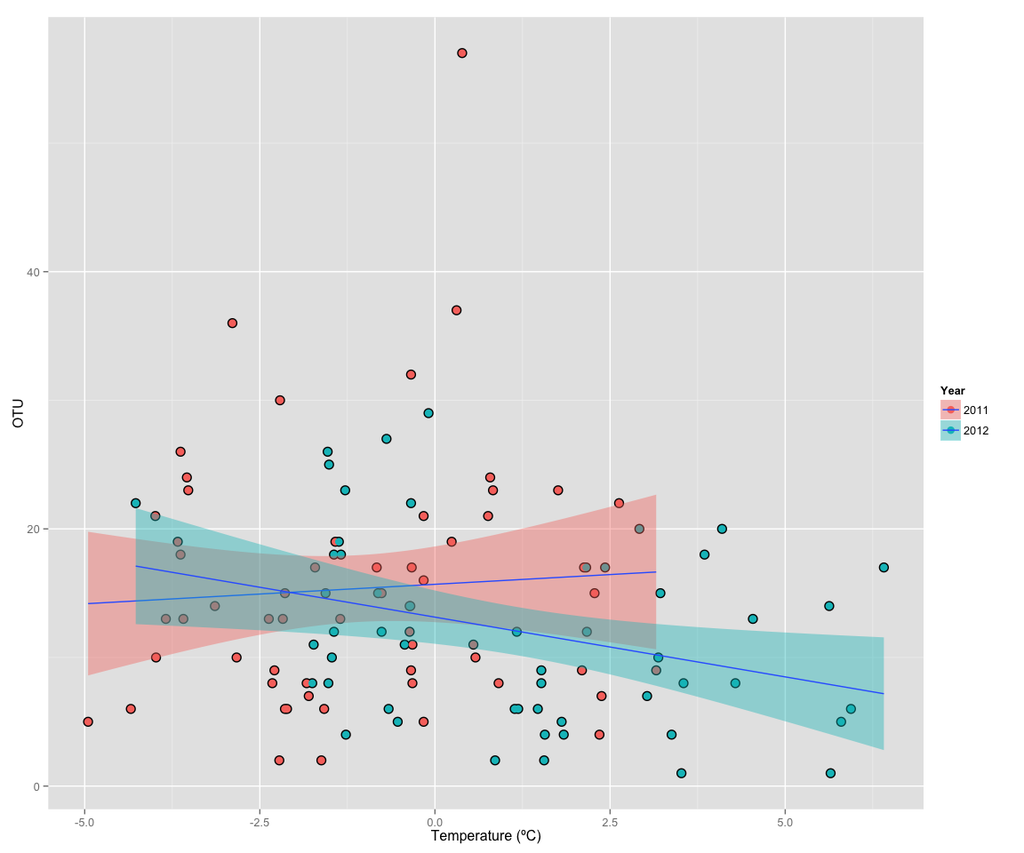

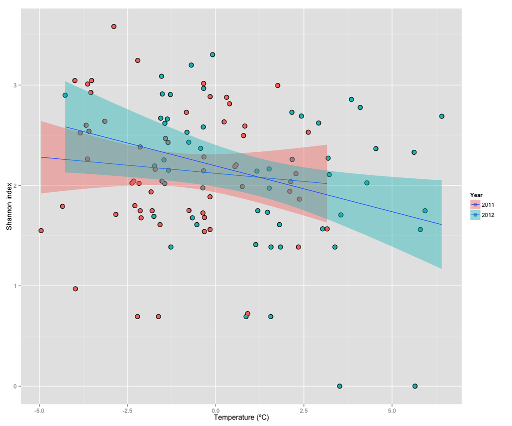

However, precipitation seems to have a more visible pattern plotting this against the number of species for both years.

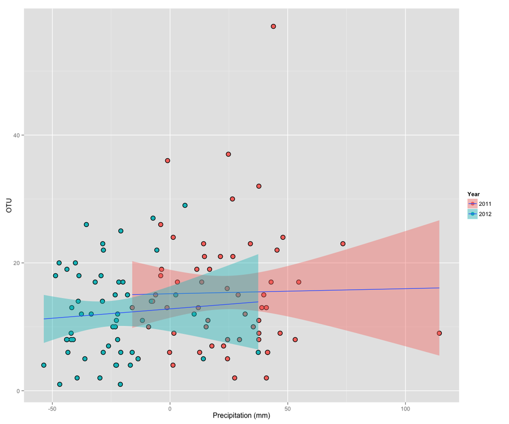

```r
#Evaluation of the effect of precipitation on the number of species
ggplot(data=oomy_data, aes(x=ct.precp, y=OTU)) +
  geom_point(colour="Black", size=4) + geom_point(aes(colour=Year), size=3) + stat_smooth(method=lm, aes(fill=Year)) + labs(x="Precipitation (mm)", y="OTU")
```

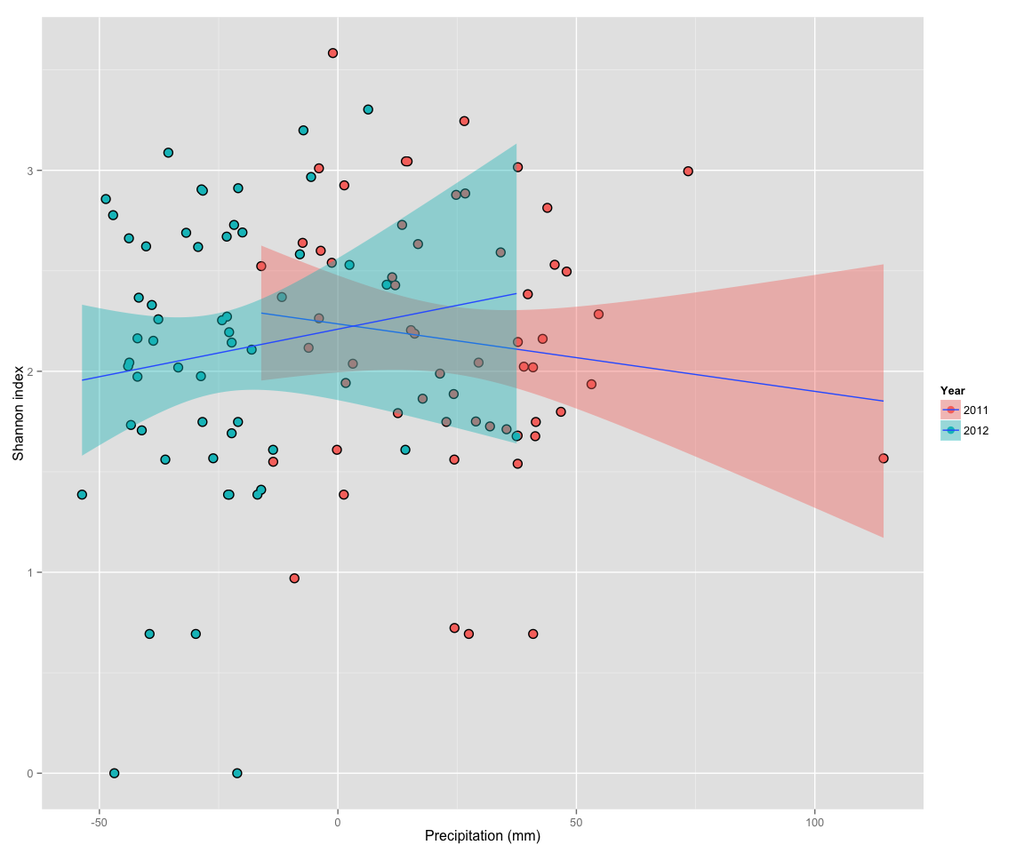

```r
#Evaluation of the effect of precipitation on the Shannon diversity index
ggplot(data=oomy_data, aes(x=ct.precp, y=shannon)) +
   geom_point(colour="Black", size=4) + geom_point(aes(colour=Year), size=3) + stat_smooth(method=lm, aes(fill=Year)) + labs(x="Precipitation (mm)", y="Shannon index")
```

Evaluation of latitude in relation to species diversity, in order to explore the relationships, and also test a ecological perspective.

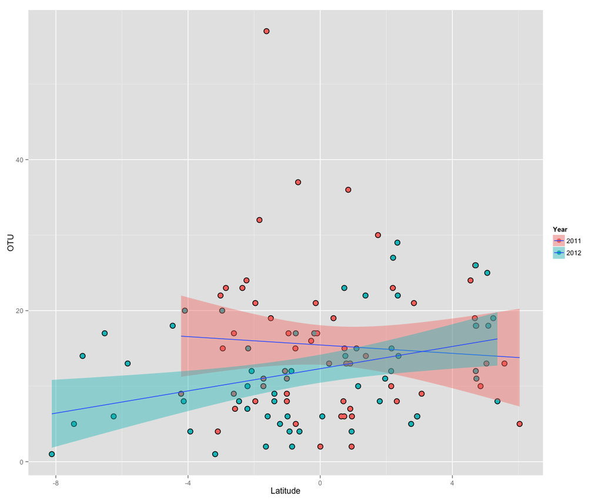

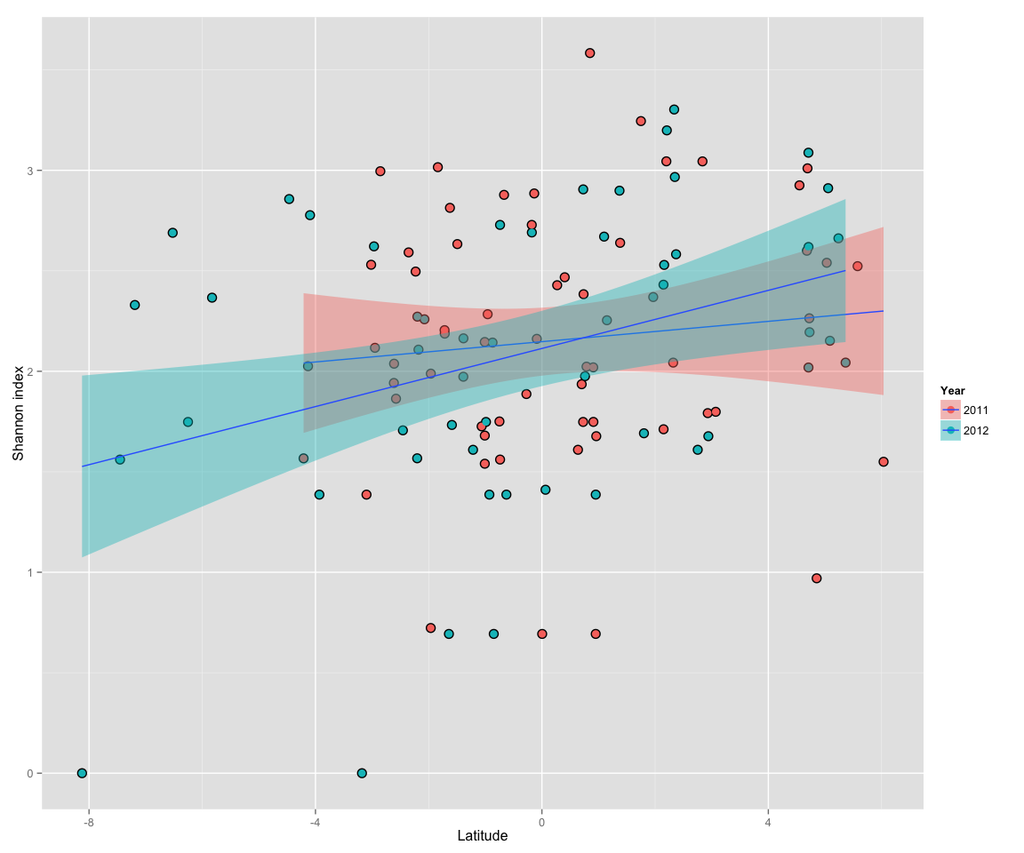

As part of the model selection, different linear models were set, using diversity (Shannon index and OTU) as response variable, using temperature, latitude, precipitation as predictor variables.

```r
reg.null <- lm(shannon ~ 1, data=oomy_data)
reg.lat <- lm(shannon ~ ct.lat, data=oomy_data)
reg.temp <- lm(shannon ~ ct.temp, data=oomy_data)
reg.prec <- lm(shannon ~ ct.precp, data=oomy_data)
reg.lat.temp <- lm(shannon ~ ct.lat + ct.temp, data=oomy_data)
reg.lat.prec <- lm(shannon ~ ct.lat + ct.precp, data=oomy_data)
reg.temp.prec <- lm(shannon ~ ct.precp + ct.precp, data=oomy_data)
reg.latXtemp <- lm(shannon ~ ct.lat*ct.temp, data=oomy_data)
reg.latXprec <- lm(shannon ~ ct.lat*ct.precp, data=oomy_data)
reg.tempXprec <- lm(shannon ~ ct.precp*ct.precp, data=oomy_data)

reg2.null <- lm(OTU ~ 1, data=oomy_data)
reg2.lat <- lm(OTU ~ ct.lat, data=oomy_data)
reg2.temp <- lm(OTU ~ ct.temp, data=oomy_data)
reg2.prec <- lm(OTU ~ ct.precp, data=oomy_data)
reg2.lat.temp <- lm(OTU ~ ct.lat + ct.temp, data=oomy_data)
reg2.lat.prec <- lm(OTU ~ ct.lat + ct.precp, data=oomy_data)
reg2.temp.prec <- lm(OTU ~ ct.precp + ct.precp, data=oomy_data)
reg2.latXtemp <- lm(OTU ~ ct.lat*ct.temp, data=oomy_data)
reg2.latXprec <- lm(OTU ~ ct.lat*ct.precp, data=oomy_data)
reg2.tempXprec <- lm(OTU ~ ct.precp*ct.precp, data=oomy_data)
```

All the models were evaluated with delta AIC to determine the best fitting model using Shannon diversity index as a response variable.

```r
#AIC selection of model using OTU as response
aic.shannon
```

```
##               dAIC df weight
## reg.lat       0.0  3  0.3867
## reg.temp      1.8  3  0.1560
## reg.lat.prec  2.0  4  0.1445
## reg.lat.temp  2.0  4  0.1423
## reg.latXprec  3.6  5  0.0635
## reg.latXtemp  3.9  5  0.0542
## reg.null      5.5  2  0.0246
## reg.prec      7.4  3  0.0094
## reg.temp.prec 7.4  3  0.0094
## reg.tempXprec 7.4  3  0.0094
```

All the models were evaluated with delta AIC to determine the best fitting model using OTU number as a response variable.

```r
#AIC selection of model using OTU as response
aic.OTU
```

```
##                dAIC df weight
## reg2.latXprec  0.0  5  0.153
## reg2.temp      0.1  3  0.144
## reg2.lat.prec  0.2  4  0.140
## reg2.prec      0.6  3  0.114
## reg2.temp.prec 0.6  3  0.114
## reg2.tempXprec 0.6  3  0.114
## reg2.lat       1.2  3  0.083
## reg2.null      1.8  2  0.061
## reg2.lat.temp  2.1  4  0.053
## reg2.latXtemp  3.7  5  0.024
```

The best fitting models were selected based on the delta AIC and other parameters were evaluated to confirm the selection of these models for both responses: Shannon diversity index and OTU number.

```r
#AIC, logLik and PRsq values for model using shannon
stargazer(AIC.shannon, type="text", summary = FALSE)
```

```
##
## =======================
##              df   AIC
## -----------------------
## reg.lat      3  227.981
## reg.lat.temp 4  229.981
## reg.latXtemp 5  231.911
## reg.latXprec 5  231.594
## -----------------------
```

```r
log.lik.shannon
```

```
## [1] -110.9904 -110.9904 -110.9554 -110.7970
```

```r
sapply(models.shannon,PRsq)
```

```
##                     [,1]       [,2]       [,3]       [,4]
## FullModelRsquared   0.06486524 0.06486554 0.06545018 0.06808954
## FullModelAdjustedR2 0.05636401 0.04770711 0.03949046 0.04220314
## partials            List,2     List,2     List,2     List,2
```

```r
#Summary for models using Shannon
stargazer(models.shannon, type="text", digits=3, omit.stat="f", omit.table.layout="n")
```

```
##
## =======================================================================================
##                                             Dependent variable:
##                     -------------------------------------------------------------------
##                                                   shannon
##                           (1)              (2)              (3)              (4)
## ---------------------------------------------------------------------------------------
## ct.lat                  0.056***          0.056            0.056           0.049**
##                         (0.020)          (0.042)          (0.042)          (0.024)
##
## ct.temp                                  -0.0003           0.002
##                                          (0.051)          (0.052)
##
## ct.lat:ct.temp                                             0.002
##                                                           (0.007)
##
## ct.precp                                                                   -0.0002
##                                                                            (0.002)
##
## ct.lat:ct.precp                                                            -0.0004
##                                                                            (0.001)
##
## Constant                2.123***         2.123***         2.135***         2.125***
##                         (0.062)          (0.062)          (0.078)          (0.063)
##
## ---------------------------------------------------------------------------------------
## Observations              112              112              112              112
## R2                       0.065            0.065            0.065            0.068
## Adjusted R2              0.056            0.048            0.039            0.042
## Residual Std. Error 0.658 (df = 110) 0.661 (df = 109) 0.664 (df = 108) 0.663 (df = 108)
## =======================================================================================
```

```r
#AIC, logLik and PRsq values for models using OTU
stargazer(AIC.otu, type="text", summary = FALSE)
```

```
##
## ========================
##               df   AIC
## ------------------------
## reg2.latXprec 5  805.474
## reg2.temp     3  805.604
## reg2.lat.prec 4  805.653
## ------------------------
```

```r
log.lik.OTU
```

```
## [[1]]
## 'log Lik.' -397.7368 (df=5)
##
## [[2]]
## 'log Lik.' -399.8022 (df=3)
##
## [[3]]
## 'log Lik.' -398.8263 (df=4)
```

```r
sapply(models.OTU,PRsq)
```

```
##                     [,1]       [,2]       [,3]
## FullModelRsquared   0.06752698 0.03249472 0.04920817
## FullModelAdjustedR2 0.04162496 0.02369922 0.03176245
## partials            List,2     List,2     List,2
```

```r
#Summary for models usig OTU
stargazer(models.OTU, type="text", digits=3, omit.stat="f", omit.table.layout="n")
```

```
##
## ======================================================================
##                                    Dependent variable:
##                     --------------------------------------------------
##                                            OTU
##                           (1)              (2)              (3)
## ----------------------------------------------------------------------
## ct.lat                   0.192                             0.413
##                         (0.306)                           (0.268)
##
## ct.precp                 0.028                             0.044*
##                         (0.028)                           (0.025)
##
## ct.lat:ct.precp          -0.014
##                         (0.010)
##
## ct.temp                                  -0.623*
##                                          (0.324)
##
## Constant               13.831***        13.768***        13.768***
##                         (0.813)          (0.819)          (0.816)
##
## ----------------------------------------------------------------------
## Observations              112              112              112
## R2                       0.068            0.032            0.049
## Adjusted R2              0.042            0.024            0.032
## Residual Std. Error 8.589 (df = 108) 8.669 (df = 110) 8.633 (df = 109)
## ======================================================================
```

Evaluation of coefficient plots for shannon diversity index and OTU number.

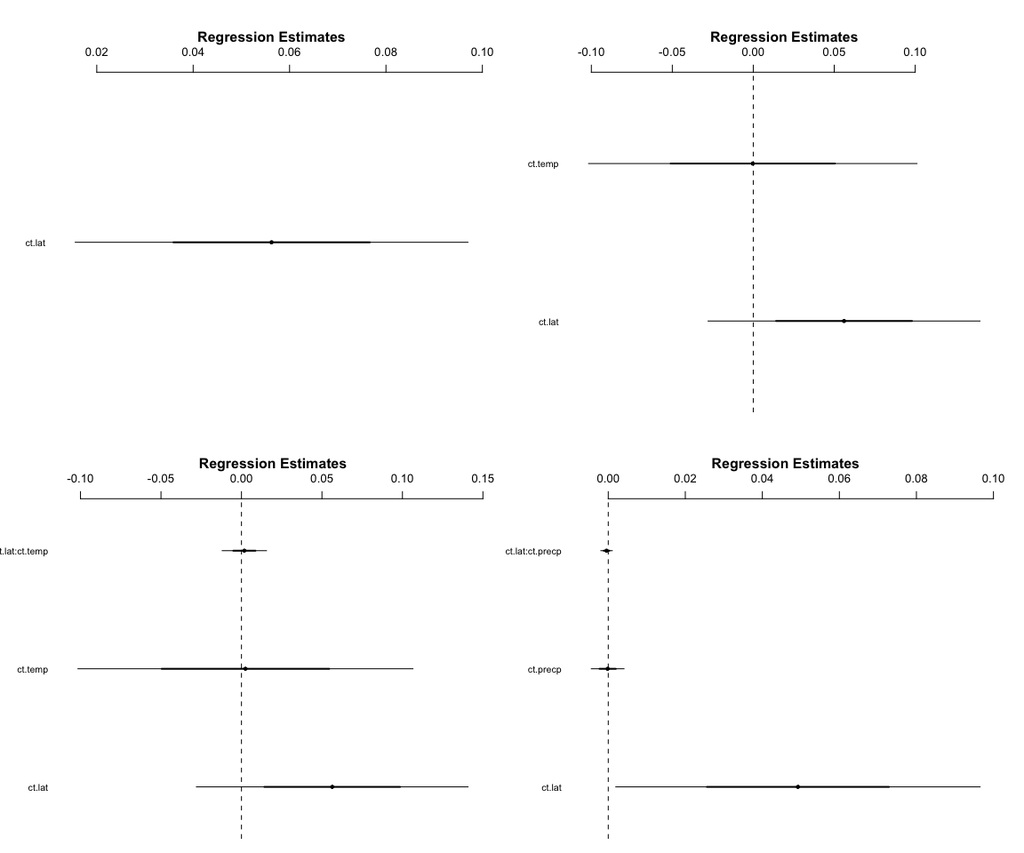

```r
#Coefficient plots for Shannon diversity index
par(mfrow = c(2,2))
sapply(models.shannon,coefplot)
```

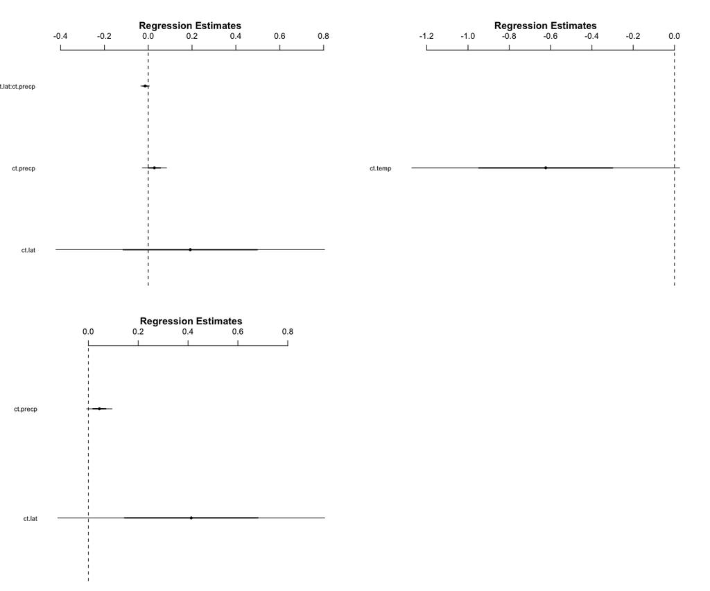

```r
#Coefficient plots for OTU number
par(mfrow = c(2,2))
sapply(models.OTU,coefplot)
```

Evaluation of ACF on the residuals for the different models for both responses

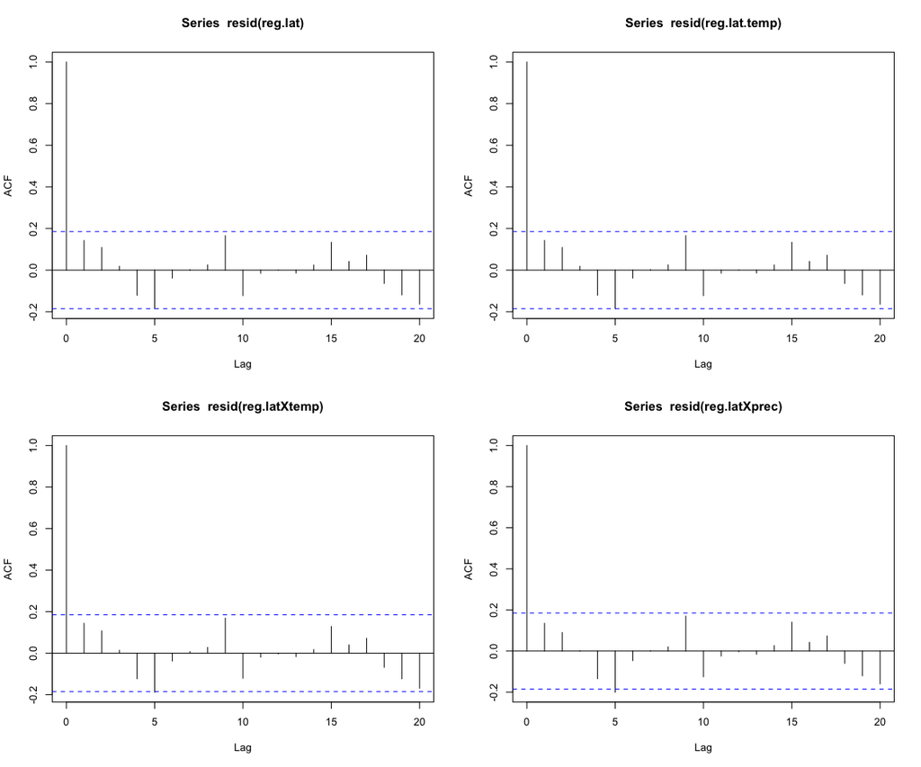

```r
#ACF for models using Shannon
par(mfrow = c(2,2))
acf(resid(reg.lat))
acf(resid(reg.lat.temp))
acf(resid(reg.latXtemp))
acf(resid(reg.latXprec))
```

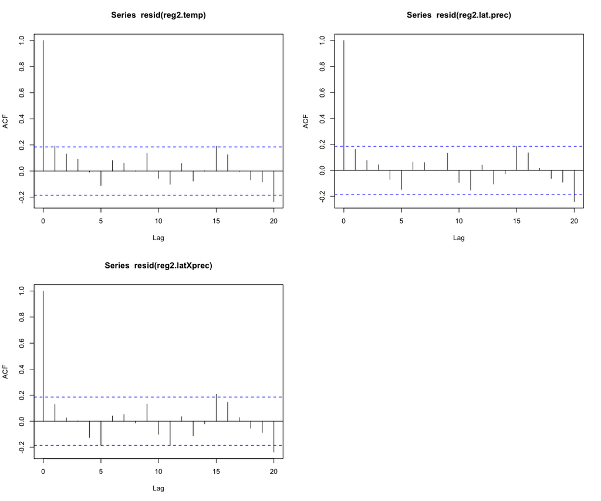

```r
#ACF for models using Shannon
par(mfrow = c(2,2))
acf(resid(reg2.temp))
acf(resid(reg2.lat.prec))
acf(resid(reg2.latXprec))
```

Evaluation VIF terms for best fitted complex models

```r
#Shannon diversity model
vif(reg.lat.temp)
```

```
##   ct.lat  ct.temp
## 4.210666 4.210666
```

```r
#OTU number model
vif(reg2.latXprec)
```

```
##          ct.lat        ct.precp ct.lat:ct.precp
##        1.327676        1.188072        1.534181
```

Plotting of diagnostic plots for best fitted complex models

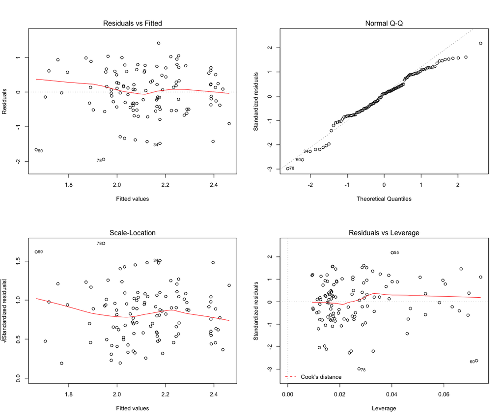

```r
par(mfrow = c(2,2))
#Shannon diversity model
plot(reg.lat.temp)
```

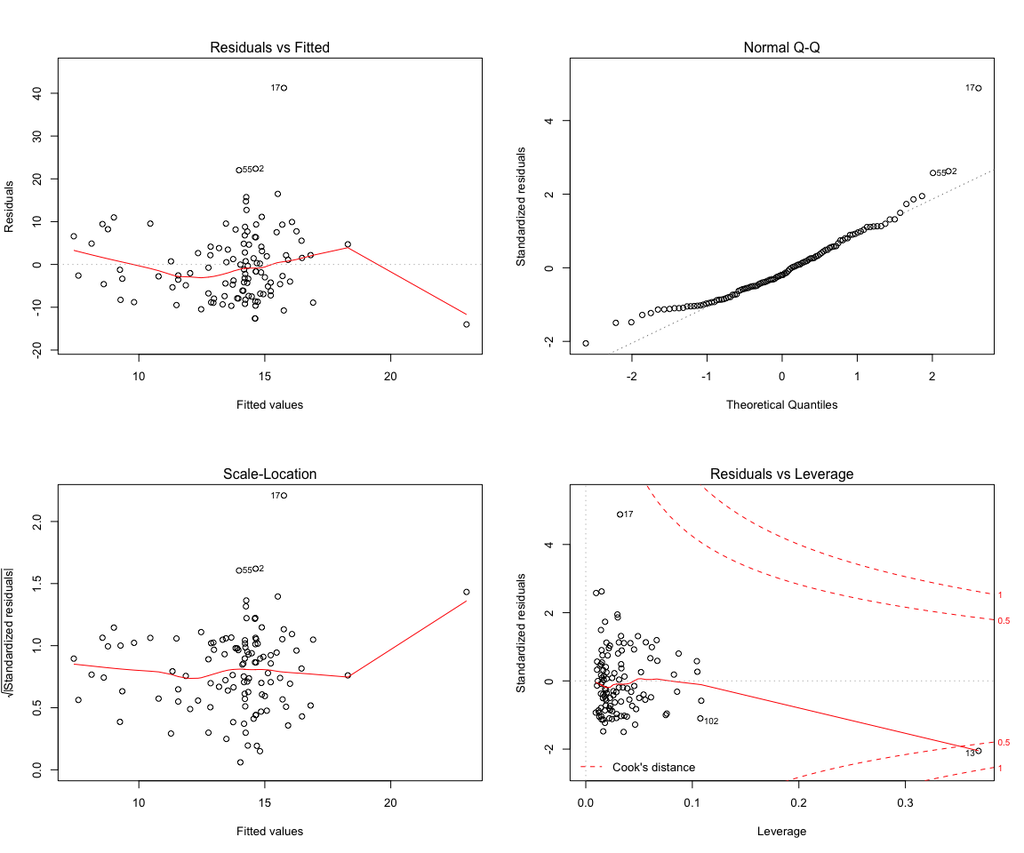

```r
#OTU number model
plot(reg2.latXprec)
```

**residuals resampling for model based on Shannon ~ lat + temp**

```r
resid.lm.boot <- function(mod.obj=reg.lat.temp, dat=oomy_data) {
  resids=resid(mod.obj)
  fit.val=fitted(mod.obj)
  mod.matr <- model.matrix(mod.obj)
  #generating new values for each y[i] (vector Y), by adding the bootstrapped residuals to the fitted model.
  Y <- fit.val + sample(resids,length(resids), replace=T)
  model.boot <- lm( Y ~ 0 + mod.matr, data=dat) # refit model with new Y values
  coef(model.boot) # Extract the co-efficients
  }

N.boot = 5000
residual.boot.N <- t(replicate(N.boot, resid.lm.boot()))
colnames(residual.boot.N) <- c("Intercept","Latitude","Temperature")
```

**Histograms of coefficients after bootstrap residual resampling for shannon ~ lat + temp**

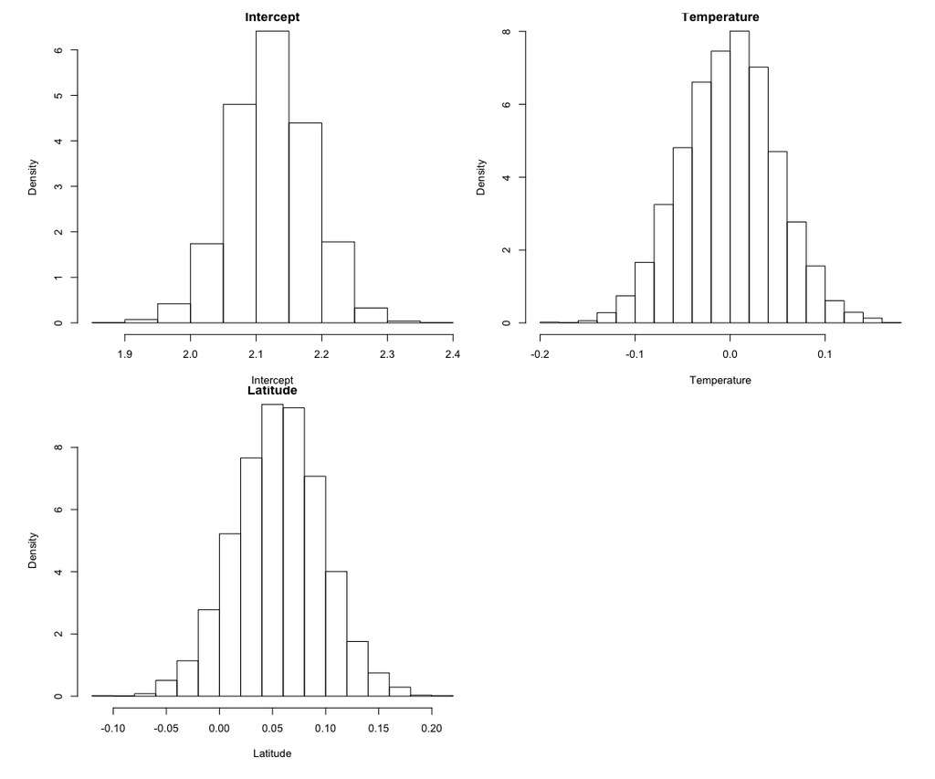

**residuals resampling for model based on OTU ~ lat + prec + lat*prec**

```r
resid.lm.boot2 <- function(mod.obj=reg2.latXprec, dat=oomy_data) {
  resids=resid(mod.obj)
  fit.val=fitted(mod.obj)
  mod.matr <- model.matrix(mod.obj)
  #generating new values for each y[i] (vector Y), by adding the bootstrapped residuals to the fitted model.
  Y <- fit.val + sample(resids,length(resids), replace=T)
  model.boot <- lm( Y ~ 0 + mod.matr, data=dat) # refit model with new Y values
  coef(model.boot) # Extract the co-efficients
  }

N.boot2 = 5000
residual.boot.N2 <- t(replicate(N.boot2, resid.lm.boot2()))
colnames(residual.boot.N2) <- c("Intercept","Latitude","Precipitation","Lat:Precp")
```

**Histograms of coefficients after bootstrap residual resampling for OTU ~ lat + prec + lat*prec**

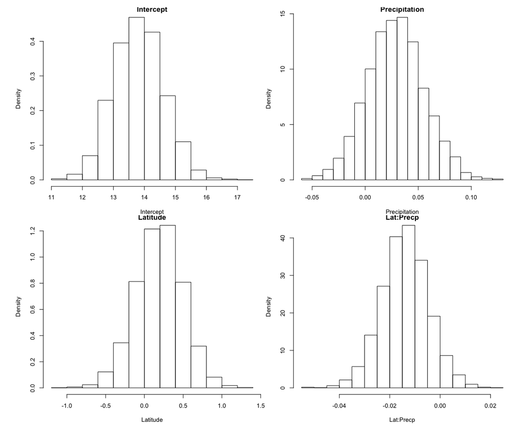

```r
par(mfcol=c(2,2), mar=c(4,4,0.5,0.5), oma=c(1.5,2,1,1))
MultipleHistograms2()
```

Power analysis for model shannon ~ lat + temp

```
## [1] 110   2
```

```
## [1]  110 1000
```

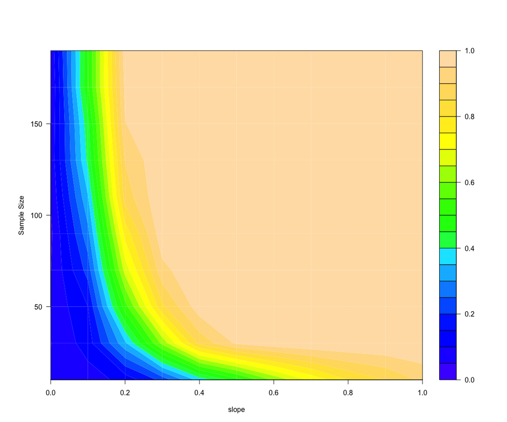

Power analysis for model OTU ~ lat + prec + lat*prec

```
## [1] 110   2
```

```
## [1]  110 1000
```

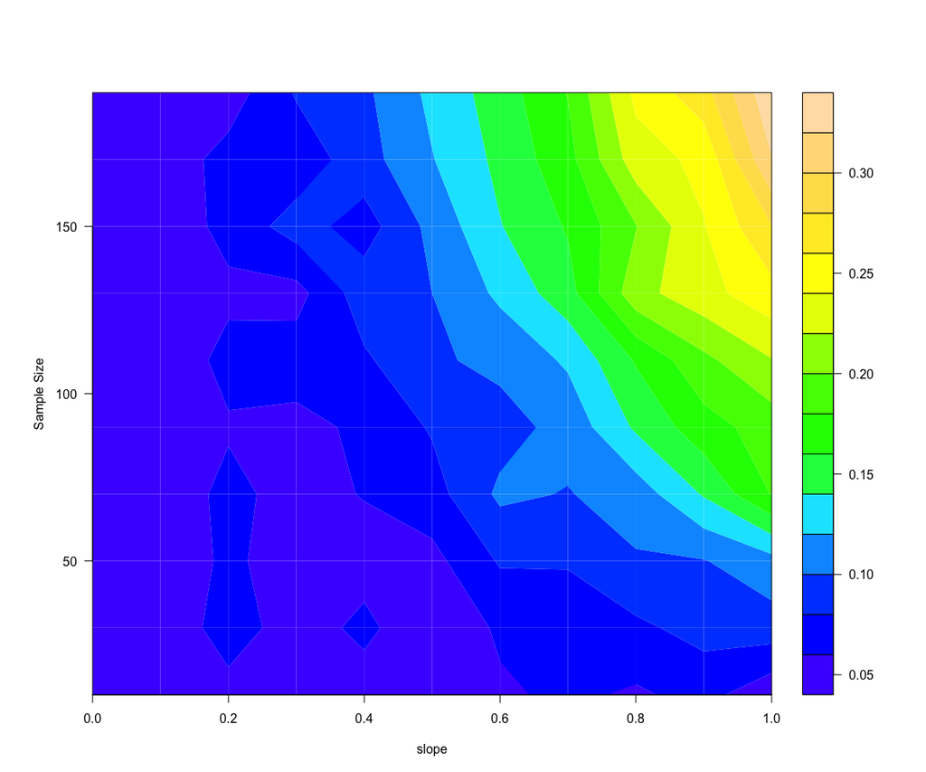

```r
#Mixed models
M.1 <- gls(shannon ~ ct.lat + ct.temp + Year, data=oomy_data, correlation = corCompSymm(form=~Year))
M.2 <- gls(OTU ~ ct.lat*ct.precp + Year, data=oomy_data, correlation = corCompSymm(form=~Year))
```

```r
stargazer(M.1,M.2, type="text")
```

```
##
## ================================================
##                         Dependent variable:
##                     ----------------------------
##                        shannon          OTU
##                          (1)            (2)
## ------------------------------------------------
## ct.lat                  0.068          0.138
##                        (0.055)        (0.311)
##
## ct.temp                 0.017
##                        (0.073)
##
## ct.precp                              -0.005
##                                       (0.042)
##
## Year2012                -0.060        -2.649
##                        (0.181)        (2.589)
##
## ct.lat:ct.precp                       -0.015
##                                       (0.010)
##
## Constant               2.152***      15.115***
##                        (0.108)        (1.494)
##
## ------------------------------------------------
## Observations             112            112
## Log Likelihood         -118.633      -401.557
## Akaike Inf. Crit.      249.266        817.113
## Bayesian Inf. Crit.    265.359        835.823
## ================================================
## Note:                *p<0.1; **p<0.05; ***p<0.01
```